# Spectrogram data - devin de araujo

## spectrogram data

### info

- `sr` = sampling rate in (Hz)
- `frame` = short audio clip
- `n_fft` = samples per frame
- `hop_length` = # samples between frames

### Frequent Furrier Transform

- use a `log` y_axis instead of linear. Why? Because all of the information is at the bottom of the plot, the log version brings this out
- see [this](https://www.youtube.com/watch?v=MhOdbtPhbLU)

### Constant Q transform

- doing log spaced freq representation
- here one vertical move is one shift in semitone

### Reading

- [MIR](https://musicinformationretrieval.com/chroma.html) this will be very useful
- [WIKI](https://en.wikipedia.org/wiki/Short-time_Fourier_transform)
- [paper](https://dawenl.github.io/publications/McFee15-librosa.pdf)
- [medium](https://medium.com/analytics-vidhya/understanding-the-mel-spectrogram-fca2afa2ce53)
- [music genre classification](https://towardsdatascience.com/musical-genre-classification-with-convolutional-neural-networks-ff04f9601a74)
  - [git](https://github.com/lelandroberts97/Musical_Genre_Classification/blob/master/code/01_Data_Gathering.ipynb)
  - uses the numpy arrays not the images!
- [getting to know mel spec](https://towardsdatascience.com/getting-to-know-the-mel-spectrogram-31bca3e2d9d0)

### Things to try

- train with smaller image sizes, then create a new data bunch and you can actually load that data back into the model, then change the `size` to something bigger and train for longer.
  - J.Howard says he hasn't gotten much better results with smaller than 64, but could be worth a try
- after first round of training, do `lr_find()` again, check the learning rate and pick a new one, using a slice
- `lr` of `3e-3` generally works well for the first round of training before unfreezing
- then for second round, for the first part of the slice use 10x lower for second part of slice, then whatever `lr_finder` found for the first part of the slice
  - `learn.fit_one_cycle(4, 3e-3)`
  - `learn.unfreeze()`
  - `learn.fit_one_cycle(4, slice("lr_finder number",3e-4))`

```python
import matplotlib.pyplot as plt
import IPython.display as ipd

import librosa
import librosa.display

from pathlib import Path
import numpy as np

%matplotlib inline
```

```python
path = Path.cwd()/'music_data'
path
```

```
PosixPath('/Users/devindearaujo/Desktop/fastai/music_data')
```

## Mel Spec loop

```python
# this script will compute STFT specto grams
# not the best for pitch

folders = ['C3', 'D3', 'E3', 'F3', 'G3', 'A3', 'B3']

output = path.mkdir('output')

for f in folders:
    p = path/f

    for child in p.iterdir():

        if child.stem != '.DS_Store':

            # load audio wavs
            sig, fs = librosa.load(child)

            # setup plot
            plt.figure(figsize=(10, 10))

            # process spectrogram
            s = librosa.feature.melspectrogram(y=sig, sr=fs, power=2)

            librosa.display.specshow(librosa.power_to_db(s, ref=np.max))

            fname = child.stem+'.jpg'

            plt.savefig(fname=output/fname, format='jpg')
            plt.close('all');
```

## Chroma Spec loop

- chroma is good for note classificaiton, not octave classification

```python
# this will convert to
folders = ['Cs3', 'Ds3', 'Fs3', 'Gs3', 'As3']
#folders = ['C3', 'D3', 'E3', 'F3', 'G3', 'A3', 'B3']


for f in folders:
    p = path/f

    for child in p.iterdir():

        if child.stem != '.DS_Store':

            # load audio wavs
            y, sr = librosa.load(child)

            # setup plot
            plt.figure(figsize=(8, 8))

            # process spectrogram
            C = librosa.feature.chroma_cqt(y=y, sr=sr)

            librosa.display.specshow(C); #y_axis='cqt_note' axis label is hidden

            fname = child.stem+'.jpg'

            plt.savefig(fname=p/fname, format='jpg')
            plt.close('all');
```

# Pitch or frequency detection

- the `estimate_pitch` function returns a pretty close apporximation of `f0`
- checked against [this](https://pages.mtu.edu/~suits/notefreqs.html)

```python
y, sr = librosa.load(path/'E3/E3_21.wav', mono=True)

librosa.core.hz_to_note(440)

librosa.core.note_to_hz('C3')

# Estimate the tuning of an audio time series or spectrogram input.
librosa.core.pitch.estimate_tuning(y,sr)


pitches, magnitudes = librosa.piptrack(y=y, sr=sr, threshold=1, ref=np.mean)
pitches.shape, magnitudes.shape
```

```
((1025, 87), (1025, 87))
```

```python
def estimate_pitch(segment, sr, fmin=50.0, fmax=2000.0):

    # Compute autocorrelation of input segment.
    r = librosa.autocorrelate(segment)

    # Define lower and upper limits for the autocorrelation argmax.
    i_min = sr/fmax
    i_max = sr/fmin
    r[:int(i_min)] = 0
    r[int(i_max):] = 0

    # Find the location of the maximum autocorrelation.
    i = r.argmax()
    f0 = float(sr)/i
    return f0

estimate_pitch(y,sr)
```

```
165.78947368421052
```

# Spectrogram investigation

```python
y, sr = librosa.load(path/'G3/G3_21.wav', mono=True)
ipd.Audio(y, rate=sr)
```

[interactive chart not shown]

```python
## Log y_axis

y, sr = librosa.load(path/'E3/E3_25.wav')
#plt.figure(figsize=(4,4))

D = librosa.amplitude_to_db(np.abs(librosa.stft(y)), ref=np.max)

#librosa.display.specshow(D, y_axis='log');

y.shape, D.shape
```

```
((44100,), (1025, 87))
```

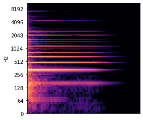

```python
## Log y_axis

y, sr = librosa.load(path/'E3/E3_25.wav')
plt.figure(figsize=(4,4))

D = librosa.amplitude_to_db(np.abs(librosa.stft(y)), ref=np.max)

librosa.display.specshow(D, y_axis='log');
```

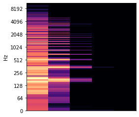

```python
## Log y_axis STFT with different hop_lengths

y, sr = librosa.load(path/'F3/F3_2.wav')
plt.figure(figsize=(4,4))

D = librosa.amplitude_to_db(np.abs(librosa.stft(y, hop_length=10000)), ref=np.max)

librosa.display.specshow(D, y_axis='log');
```

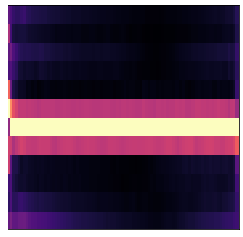

```python
y, sr = librosa.load(path/'F3/F3_25.wav')
plt.figure(figsize=(6,6))


C = librosa.feature.chroma_cqt(y=y, sr=sr)

librosa.display.specshow(C); #y_axis='cqt_note'
```

### Loop through

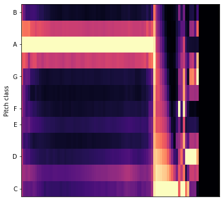

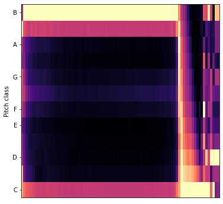

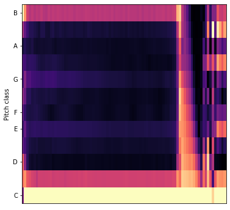

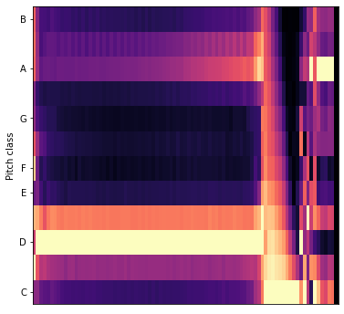

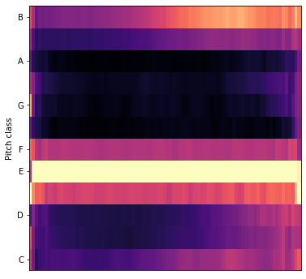

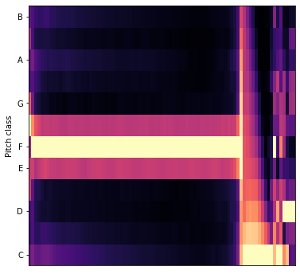

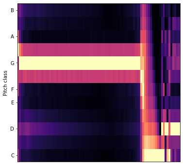

```python
p = path/'test'

for w in p.iterdir():

    if w.stem != '.DS_Store':

        y, sr = librosa.load(w)

        plt.figure(figsize=(6, 6))

        C = librosa.feature.chroma_cqt(y=y, sr=sr)
        librosa.display.specshow(C, y_axis='chroma');
        #plt.close()
```

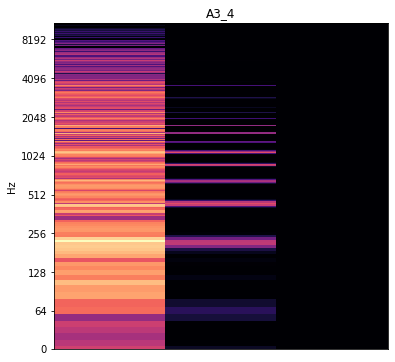

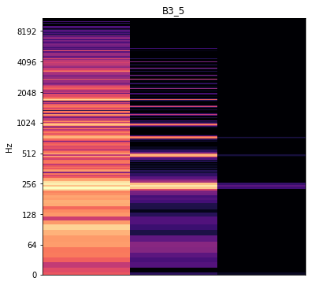

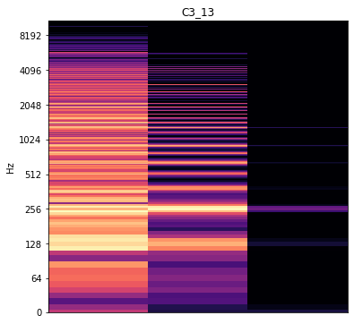

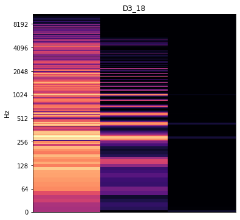

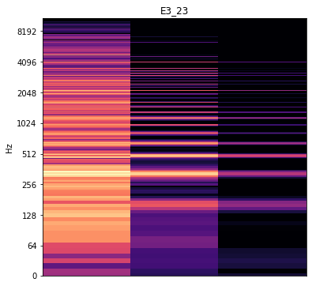

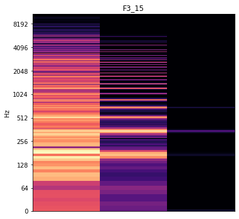

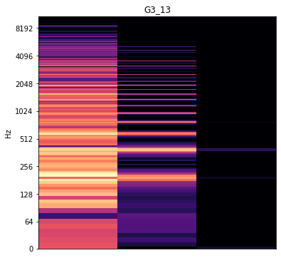

```python
p = path/'test'

for w in p.iterdir():

    if w.stem != '.DS_Store':

        y, sr = librosa.load(w)

        plt.figure(figsize=(6, 6))

        D = librosa.amplitude_to_db(np.abs(librosa.stft(y, hop_length=15000)), ref=np.max)

        plt.title(w.stem)
        librosa.display.specshow(D, y_axis='log');
```

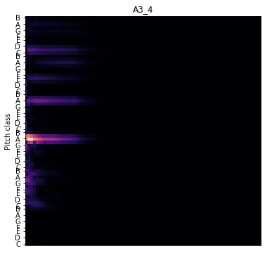

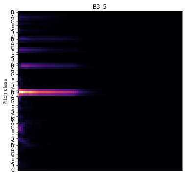

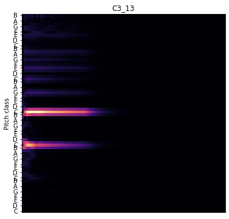

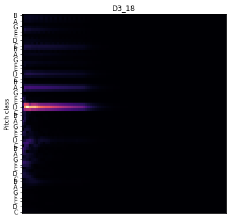

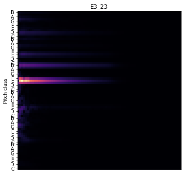

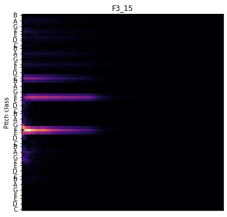

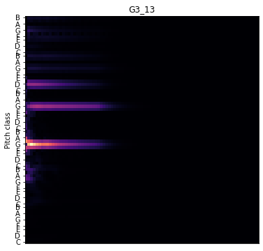

```python
p = path/'test'

for w in p.iterdir():

    if w.stem != '.DS_Store':

        y, sr = librosa.load(w)

        plt.figure(figsize=(6, 6))

        C = librosa.cqt(y=y, sr=sr, n_bins=72)

        plt.title(w.stem)
        # plot the log
        #logC = librosa.amplitude_to_db(np.abs(C))

        librosa.display.specshow(np.abs(C), y_axis='chroma');
```